# Introduction to Text Ming Package (TM)

# Introduction to Text Ming Package (TM)

In this article, we present to you the usual workflow of using text mining packages, i.e., `TM` and `wordcloud`, and the text mining framework. We will analyze the word frequencies from different text files and eventually create a nice word cloud out of the shared words across documents and visualize the distribution of the frequent words.

## Import data

In this tutorial, we will be using [works](https://raw.githubusercontent.com/angerhang/statsTutorial/master/src/textMining/data/pg100.txt) by Shakespeare. In order to have a better view of Corpus and word count matrix, we divide the original text file into three and you can download them from 1.txt, 2.txt and 3.txt.

Alternatively you can just run the following commands the download and store the files in a folder called `data`:

```r
library(RCurl)
dir.create("data")
setwd("data")
url <- "https://raw.githubusercontent.com/angerhang/statsTutorial/master/src/textMining/data/1.txt"
write(getURL(url), file = "1.txt")
url <- "https://raw.githubusercontent.com/angerhang/statsTutorial/master/src/textMining/data/2.txt"
write(getURL(url), file = "2.txt")
url <- "https://raw.githubusercontent.com/angerhang/statsTutorial/master/src/textMining/data/3.txt"
write(getURL(url), file = "3.txt")
setwd("..")
```

```r
library(tm)
```

```r
## Loading required package: NLP
```

```r
shakespeare <- VCorpus(DirSource("data", encoding = "UTF-8"))
shakespeare
```

```r
## <>
## Metadata:  corpus specific: 0, document level (indexed): 0
## Content:  documents: 4
```

```r
twoPhrases <- c("Phrase one ", "Phrase two")
simpleCorpus <- VCorpus(VectorSource(twoPhrases))
simpleCorpus
```

```r
## <>
## Metadata:  corpus specific: 0, document level (indexed): 0
## Content:  documents: 2
```

If you want to export the your `Corpus` for to used by other tools. Simply use

```r
writeCorpus(shakespeare)
```

which will output the documents to multiple files in the `Corpus` to the hard disk.

## Corpus mainipulation

There are many methods we can use to play with `Corpus`. Each `Corpus` has its own meta data and each document in the `Corpus` also has one.

```r
meta(shakespeare[[1]])
```

```r
##   author       : character(0)
##   datetimestamp: 2016-04-25 13:39:24
##   description  : character(0)
##   heading      : character(0)
##   id           : 1.txt
##   language     : en
##   origin       : character(0)
```

One can see the document content and get an overview of one `Corpus` using

```r
shakespeare[[1]]
summary(shakespeare)
```

[output not shown]

There are also other useful methods available such as `tmUpdate()` which checks the new files that do not exist yet and add those in and `inspect()` which gives a more detailed overview than `summary()`.

## Cleaning data

We now want to transform the data we have before we actually conduct out analysis. Some classical method for cleaning are removing unnecessary white space, stemming and stop words removal and conversion to lower or upper case. For the ones don't know, stop words removal is to eliminate some common words that have little value in the analysis e.g. `the` and `be`. Stem mining is to reduce derived words to their root form such as making `says`, `said` into `say` because they essentially have the same meanings. We do the cleaning with the help of `tm_map` which applies a function across all the documents.

```r
library(SnowballC)
# Remove whitespace
shakespeare <- tm_map(shakespeare, stripWhitespace, lazy=TRUE)
# Stemming
shakespeare <- tm_map(shakespeare, stemDocument, lazy=TRUE)
# Remove punctuation
shakespeare <- tm_map(shakespeare, removePunctuation, lazy=TRUE)
# Remove stopwords
tm_map(shakespeare, content_transformer(removeWords), stopwords("the"), lazy=TRUE)
```

```r
## <>
## Metadata:  corpus specific: 0, document level (indexed): 0
## Content:  documents: 4
```

```r
# Case conversion
tm_map(shakespeare, content_transformer(tolower), lazy = TRUE)
```

```r
## <>
## Metadata:  corpus specific: 0, document level (indexed): 0
## Content:  documents: 4
```

I think `tm` package requires us to put `lazy=TRUE` explicitly, otherwise we will get all scheduled cores encountered errors in user code` warning.

## Term document matrix

```r
dtm <- DocumentTermMatrix(shakespeare)
```

Essentially the frequency of a word is a representation of its importance. We have see the terms that show up more than 25 times

```r
highFreqTerms <- findFreqTerms(dtm, 25, Inf)
summary(highFreqTerms)
```

```r
##    Length     Class      Mode
##      4197 character character
```

```r
highFreqTerms[1:10]
```

```r
##  [1] "19901993" "aaron"    "abat"     "abbess"   "abbey"    "abhor"
##  [7] "abhorson" "abid"     "abil"     "abject"
```

```r
loves_assocs <- findAssocs(dtm, "love", 0.95)
```

## Visulization

#### Word Clound

A nice visualization on all the words that have frequency higher than 2500.

```r
freq <- sort(colSums(as.matrix(dtm)),decreasing=TRUE)
library(wordcloud)
```

```r
## Loading required package: RColorBrewer
```

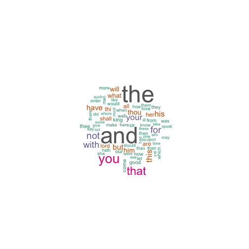

```r
set.seed(555)
wordcloud(names(freq), freq, min.freq=2500, max.words = 100, colors=brewer.pal(8, "Dark2"))
```

#### Word distribution

We now see the distribution of the 50 most frequent words in a barplot.

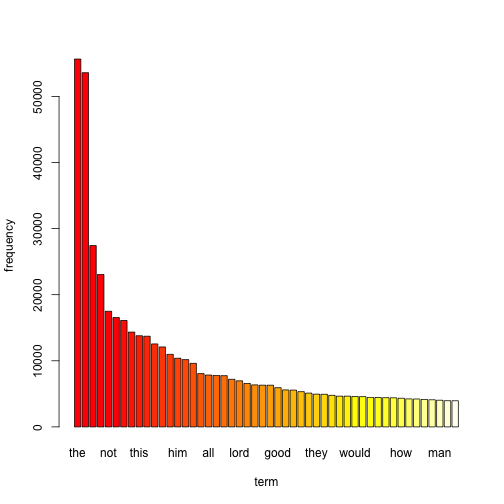

```r
barplot(freq[1:50], xlab = "term", ylab = "frequency",  col=heat.colors(50))
```

## Data source

W. Shakespeare, he Complete Works of William Shakespeare, (1994). Gutenberg EBook: http://www.gutenberg.org/ebooks/100

## References

Feinerer, Ingo. 2015. “Introduction to the Tm Package Text Mining in R.” 2013-12-01]. Http://www, Dainf, Ct. Utfpr, Edu. Br/-Kaestner/Min-Eracao/RDataMining/tm, Pdf.

Meyer, David, Kurt Hornik, and Ingo Feinerer. 2008. “Text Mining Infrastructure in R.” Journal of Statistical Software 25 (5). American Statistical

Styled with knitrBootstrap